# CTA_practice2_Group

ZHUOHAN JIANG/Xiaowen Leng/Yinuo Liu

2026-02-07

## Exercise 1

## Take a subset of the tweets data by “user_name” These names describe the name of the newspaper source of the Twitter account. Do we see different sentiment dynamics if we look only at different newspaper sources?

###load library and data

```r
library(academictwitteR) # for fetching Twitter data
```

```r
library(tidyverse) # loads dplyr, ggplot2, and others
library(readr) # more informative and easy way to import data
library(stringr) # to handle text elements
library(tidytext) # includes set of functions useful for manipulating text
library(quanteda) # includes functions to implement Lexicoder
library(textdata)
tweets  <- readRDS(gzcon(url("https://github.com/cjbarrie/CTA-ED/blob/main/data/sentanalysis/newstweets.rds?raw=true")))
```

### Inspect and filter data

```r
tweets <- tweets %>%
  select(user_username, text, created_at, user_name,
         retweet_count, like_count, quote_count) %>%
  rename(username = user_username,
         newspaper = user_name,
         tweet = text)
```

tidy text (untoken)

```r
tidy_tweets <- tweets %>%
  mutate(desc = tolower(tweet)) %>%
  unnest_tokens(word, desc) %>%
  filter(str_detect(word, "[a-z]"))
```

delect stop words

```r
tidy_tweets <- tidy_tweets %>%
    filter(!word %in% stop_words$word)
```

###gen data variable, order and format date

```r
tidy_tweets <- tidy_tweets %>%
  mutate(date = as.Date(created_at)) %>%
  group_by(newspaper, date) %>%
  mutate(order = row_number())
```

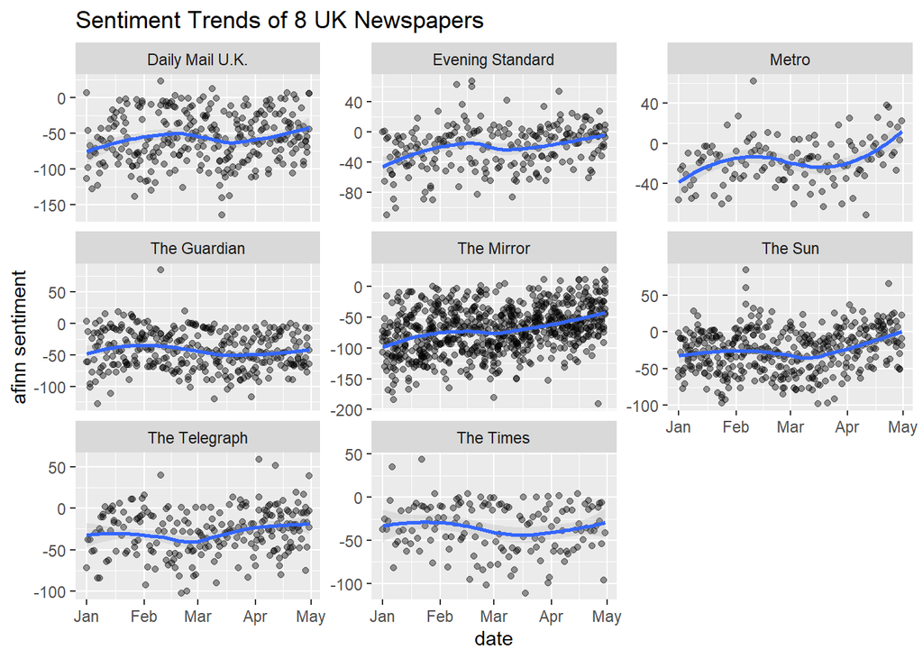

```r
#get tweet sentiment by date and newspaper
tweets_afi_sentiment <-tidy_tweets %>%
  mutate(date = as.Date(created_at)) %>%
  inner_join(get_sentiments("afinn"), by = "word") %>%
  group_by(newspaper, date, index = order %/% 1000) %>%
  summarise(sentiment = sum(value), .groups = "drop") %>%
  ggplot(aes(date, sentiment)) +
  geom_point(alpha = 0.4) +
  geom_smooth(method = "loess", alpha = 0.2) +
  facet_wrap(~ newspaper, scales = "free_y") +
  ylab("afinn sentiment") +
  ggtitle("Sentiment Trends of 8 UK Newspapers")
tweets_afi_sentiment
```

## Exercise 2

Build your own (minimal) dictionary-based filter technique and plot the result.

### Load data and packages

```r
library(kableExtra)
```

```r
library(tidyverse) # loads dplyr, ggplot2, and others
library(readr) # more informative and easy way to import data
library(stringr) # to handle text elements
library(tidytext) # includes set of functions useful for manipulating text
library(quanteda) # includes functions to implement Lexicoder
library(textdata)
library(academictwitteR) # for fetching Twitter data
```

Download the tweets data directly from the source.

```r
tweets  <- readRDS(gzcon(url("https://github.com/cjbarrie/CTA-ED/blob/main/data/sentanalysis/newstweets.rds?raw=true")))
```

### Select subset and tidy text

Select and rename relevant columns.

```r
tweets <- tweets %>%
  select(user_username, text, created_at, user_name) %>%
  rename(username = user_username,
         newspaper = user_name,
         tweet = text)
```

Convert tweets to lowercase, break the text into individual words (tokens), filter out non-alphabetic characters, and remove stop words.

```r
tidy_tweets <- tweets %>%
  mutate(desc = tolower(tweet)) %>%
  unnest_tokens(word, desc) %>%
  filter(str_detect(word, "[a-z]"))
tidy_tweets <- tidy_tweets %>%
    filter(!word %in% stop_words$word)
```

### Arrange data by date

Convert the created_at column into date format, sort the dataset by date, and assign an order column to preserve the tweet sequence

```r
tidy_tweets$date <- as.Date(tidy_tweets$created_at)

tidy_tweets <- tidy_tweets %>%
  arrange(date)

tidy_tweets$order <- 1:nrow(tidy_tweets)
```

### Create data privacy dictionary

Create a data privacy dictionary and assign a value of 1 to each word to use as a reference for counting data privacy-related terms.

```r
word <- c('privacy', 'data', 'leak','identity', 'theft', 'encryption', 'hacking', 'firewall', 'security', 'confidentiality', 'cyberattack', 'cybersecurity', 'surveillance', 'tracking','authentication')
value <- rep(1, length(word))
data_privacy <- data.frame(word, value)
data_privacy
```

```
##               word value
## 1          privacy     1
## 2             data     1
## 3             leak     1
## 4         identity     1
## 5            theft     1
## 6       encryption     1
## 7          hacking     1
## 8         firewall     1
## 9         security     1
## 10 confidentiality     1
## 11     cyberattack     1
## 12   cybersecurity     1
## 13    surveillance     1
## 14        tracking     1
## 15  authentication     1
```

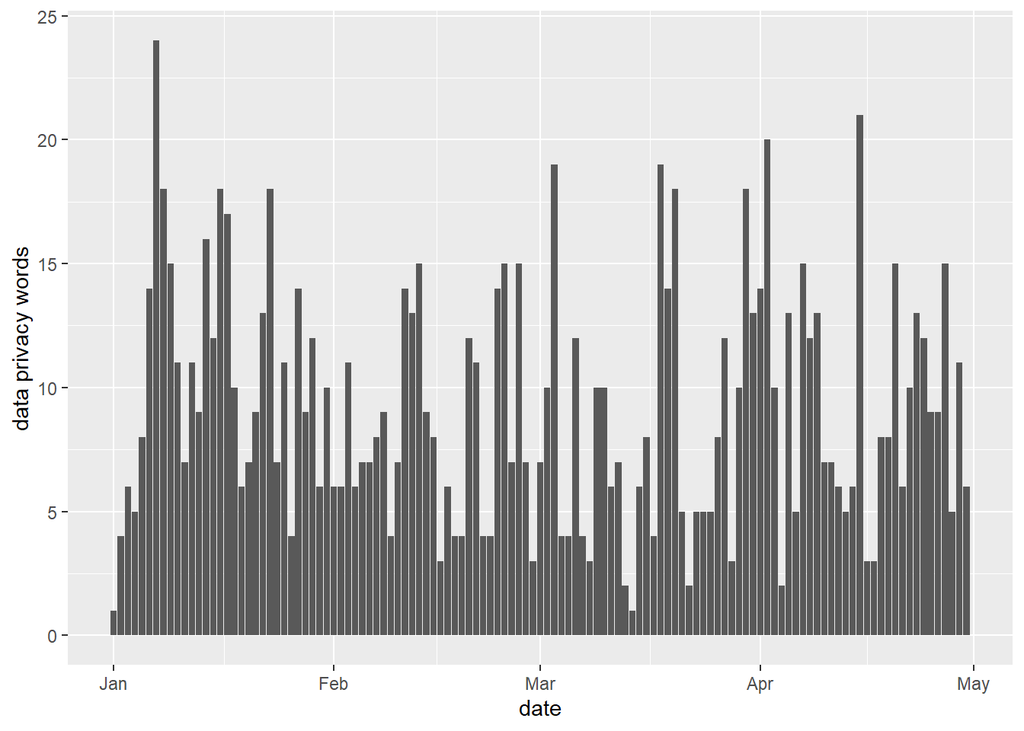

```r
tidy_tweets %>%
  inner_join(data_privacy) %>%
  group_by(date, index = order %/% 1000) %>%
  summarise(privacywords = sum(value)) %>%
  ggplot(aes(date, privacywords)) +
  geom_bar(stat= "identity") +
  ylab("data privacy words")
```

### Visualise data privacy words by percentage

This chunk calculates the percentage of data privacy words in the tweets per day. It counts the total number of words per day, then counts the occurrences of data privacy words. It then computes the percentage of data privacy words relative to the total words for each day and visualises the result as a scatter plot with a smoothed line.

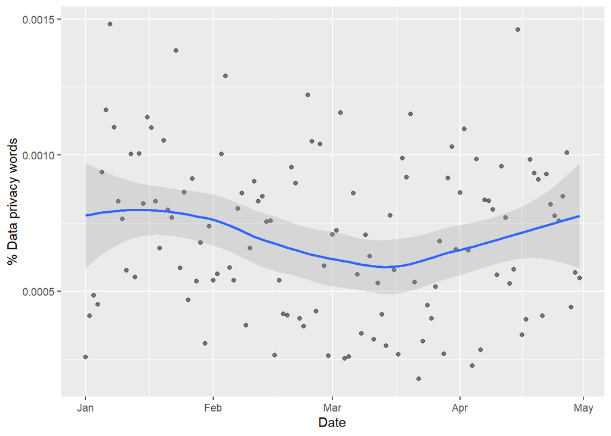

```r
# Define keyword vectors
data_privacy <- c('privacy', 'data', 'leak','identity', 'theft', 'encryption', 'hacking', 'firewall', 'security', 'confidentiality', 'cyberattack', 'cybersecurity', 'surveillance', 'tracking','authentication')

# Calculate total vocabulary per day
totals <- tidy_tweets %>%
  mutate(obs=1) %>%
  group_by(date) %>%
  summarise(sum_words = sum(obs))

# Visualise
tidy_tweets %>%
  mutate(obs=1) %>%
  filter(grepl(paste0(data_privacy, collapse = "|"), word, ignore.case = T)) %>%
  group_by(date) %>%
  summarise(sum_pwords = sum(obs)) %>%
  full_join(totals, by = "date") %>%
  mutate(
    sum_pwords = ifelse(is.na(sum_pwords), 0, sum_pwords),
    pctpwords = sum_pwords / sum_words
  ) %>%
  ggplot(aes(date, pctpwords)) +
  geom_point(alpha = 0.5) +
  geom_smooth(method = loess, alpha = 0.25) +
  xlab("Date") +
  ylab("% Data privacy words")
```

## Exercise 3

Apply the Lexicoder Sentiment Dictionary to the news tweets, but break down the analysis by newspaper.

### Load packages

```r
library(tidyverse) # loads dplyr, ggplot2, tidyr and other tidy tools
library(quanteda)  # text analysis package used here for Lexicoder sentiment dictionary
```

### Read data

```r
tweets <- readRDS(gzcon(url("https://github.com/cjbarrie/CTA-ED/blob/main/data/sentanalysis/newstweets.rds?raw=true")))
```

### Keep relevant variables and rename for clarity

```r
tweets <- tweets %>%
  select(user_username, text, created_at, user_name,
         retweet_count, like_count, quote_count) %>%
  rename(
    username = user_username,   # Twitter account (used for grouping)
    newspaper = user_name,       # newspaper display name
    tweet = text
  )
```

### Corpus construction and tokenisation

```r
# create a date variable for later aggregation
tweets$date <- as.Date(tweets$created_at)

# create a quanteda corpus object from tweet text
tweet_corpus <- corpus(tweets, text_field = "tweet", docvars = "date")
# tokenize the corpus and remove punctuation
toks_news <- tokens(tweet_corpus, remove_punct = TRUE)
```

### Apply the Lexicoder sentiment dictionary

```r
# select only the positive and negative categories from the Lexicoder dictionary
data_dictionary_LSD2015_pos_neg <- data_dictionary_LSD2015[1:2]

# apply the Lexicoder dictionary to the tokenized tweets
toks_news_lsd <- tokens_lookup(toks_news, dictionary = data_dictionary_LSD2015_pos_neg)
```

### Aggregate sentiment by newspaper

```r
# inspect docvars
docvars(toks_news_lsd)
```

[output not shown]

[output cut: 28558 more lines]

```r
# inspect available newspapers in the data
unique(docvars(toks_news_lsd)$username)
```

```
## [1] "DailyMirror"     "thetimes"        "TheSun"          "DailyMailUK"
## [5] "guardian"        "Telegraph"       "EveningStandard" "MetroUK"
```

```r
# create a document-feature matrix and aggregate sentiment by newspaper
dfm_news_lsd <- dfm(toks_news_lsd) %>%
  dfm_group(groups = username)

# convert to a data frame and compute overall sentiment (positive - negative)
tidy_dfm_news_lsd <- dfm_news_lsd %>%
  convert(to = "data.frame") %>%
  rename("newspaper" = doc_id) %>%
  mutate(sentiment = positive - negative)
```

### Figure 1: bar chart of positive and negative Lexicoder word counts by newspaper

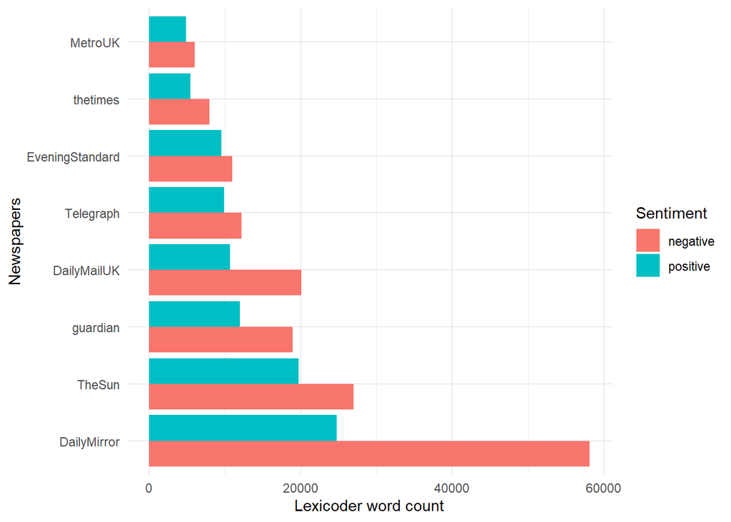

```r
# reshape the data from wide to long format so that
# positive and negative word counts can be plotted side by side
tidy_long_news_lsd <- tidy_dfm_news_lsd %>%
  select(newspaper, positive, negative) %>%
  pivot_longer(
    cols = c(positive, negative),
    names_to = "sentiment_type",
    values_to = "count"
  )

# plot the raw Lexicoder positive and negative word counts by newspaper
tidy_long_news_lsd %>%
  ggplot(aes(x = reorder(newspaper, -count),
             y = count,
             fill = sentiment_type)) +
  geom_col(position = "dodge") +
  coord_flip() +
  xlab("Newspapers") +
  ylab("Lexicoder word count") +
  labs(fill = "Sentiment") +
  theme_minimal()
```